# Math 471 Introduction to Numerical Methods

Deniz Bilman, University of Michigan. Winter 2019

## Chapter 7: Initial Value Problems for Differential Equations

RK4 Implementation: autonomous case, and then the non-autonomous case. Let's first store the Euler method as a function.

```matlab
%%file euler_na.m
function [tlist,w] = euler_na(f,x0,dt,ti,tf)
    nn = floor((tf - ti)/dt);
    dtfinal = tf - (ti + nn*dt);
    if dtfinal==0
        w = zeros(nn+1,1);
        tlist = ti:dt:tf;
    else
        w = zeros(nn+2,1);
        tlist = [ti:dt:tf, tf];
    end
    w(1) = x0;
    for i = 1:nn
        w(i+1) = w(i) + dt*f(tlist(i), w(i));
%         fprintf('Step %d:  w = %18.15f\n', i, w(i+1));
    end
    if dtfinal ~= 0
        w(nn+2) = w(nn+1) + dt*f(tlist(nn+1),w(nn+1));
%         fprintf('Step %d:  w = %18.15f\n', nn+2, w(nn+2));
    end
end
```

```
Created file '/Users/denizbilman/Dropbox/Teaching/umich Math471/jupyterLectures/euler_na.m'.
```

```matlab
%%file rk4.m
function [tlist,w] = rk4(f,x0,dt,ti,tf)
    nn = floor((tf - ti)/dt);
    dtfinal = tf - (ti + nn*dt);
    if dtfinal==0
        w = zeros(nn+1,1);
        tlist = ti:dt:tf;
    else
        w = zeros(nn+2,1);
        tlist = [ti:dt:tf, tf];
    end
    w(1) = x0;
    for i = 1:nn
        k1 = dt*f(w(i));
        k2 = dt*f(w(i) + 0.5.*k1);
        k3 = dt*f(w(i) + 0.5.*k2);
        k4 = dt*f(w(i) + k3);
        w(i+1) = w(i) + (k1 + 2*k2 + 2*k3 + k4)/6.;
        %fprintf('Step %d:  w = %18.15f\n', i, w(i+1));
    end
    if dtfinal ~= 0
        dt = dtfinal;
        k1 = dt*f(w(nn+1));
        k2 = dt*f(w(nn+1) + 0.5.*k1);
        k3 = dt*f(w(nn+1) + 0.5.*k2);
        k4 = dt*f(w(nn+1) + k3);
        w(nn+2) = w(nn+1) + (1/6)*(k1 + 2*k2 + 2*k3 + k4);
        %fprintf('Step %d:  w = %18.15f\n', nn+2, w(nn+2));
    end
end
```

```
Created file '/Users/denizbilman/Dropbox/Teaching/umich Math471/jupyterLectures/rk4.m'.
```

```matlab
%%file rk4_na.m
function [tlist,w] = rk4_na(f,x0,dt,ti,tf)
    nn = floor((tf - ti)/dt);
    dtfinal = tf - (ti + nn*dt);
    if dtfinal==0
        w = zeros(nn+1,1);
        tlist = ti:dt:tf;
    else
        w = zeros(nn+2,1);
        tlist = [ti:dt:tf, tf];
    end
    w(1) = x0;
    for i = 1:nn
        k1 = dt*f(tlist(i),w(i));
        k2 = dt*f(tlist(i)+0.5*dt,w(i) + 0.5.*k1);
        k3 = dt*f(tlist(i)+0.5*dt,w(i) + 0.5.*k2);
        k4 = dt*f(tlist(i)+dt,w(i) + k3);
        w(i+1) = w(i) + (k1 + 2*k2 + 2*k3 + k4)/6.;
%         fprintf('Step %d:  w = %18.15f\n', i, w(i+1));
    end
    if dtfinal ~= 0
        k1 = dt*f(tlist(i),w(i));
        k2 = dt*f(tlist(i)+0.5*dt,w(i) + 0.5.*k1);
        k3 = dt*f(tlist(i)+0.5*dt,w(i) + 0.5.*k2);
        k4 = dt*f(tlist(i)+dt,w(i) + k3);
        w(nn+2) = w(nn+1) + (k1 + 2*k2 + 2*k3 + k4)/6.;
%         fprintf('Step %d:  w = %18.15f\n', nn+2, w(nn+2));
    end
end
```

```
Created file '/Users/denizbilman/Dropbox/Teaching/umich Math471/jupyterLectures/rk4_na.m'.
```

Solve the IVP

$$ x'(t) = -2x(t), \quad t>0,\quad x(0)=3. $$

Compute $x(2)$. Exact solution: $x(t)=3e^{-2t}$.

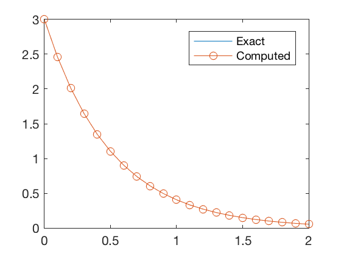

```
ans =

   1.0e-04 *

         0
    0.0774
    0.1268
    0.1557
    0.1699
    0.1739
    0.1709
    0.1632
    0.1527
    0.1407
    0.1280
    0.1152
    0.1029
    0.0913
    0.0805
    0.0706
    0.0617
    0.0536
    0.0465
    0.0402
    0.0346
```

```matlab
% Define f(x)
f = @(x) (- 2*x);
h = 0.1;
t0 = 0;
T = 2;
t = t0:h:T;
x0=3;
xexact = 3*exp(-2*t);
[tlist wlist] = rk4(f,x0,h,t0,T);
plot(t,xexact,t,wlist,'-o')
legend('Exact','Computed')
abs(wlist-xexact')
```

Solve the IVP

$$ x'(t) = 2x(t), \quad t>0,\quad x(0)=3. $$

Compute $x(2)$. Exact solution: $x(t)=3e^{2t}$.

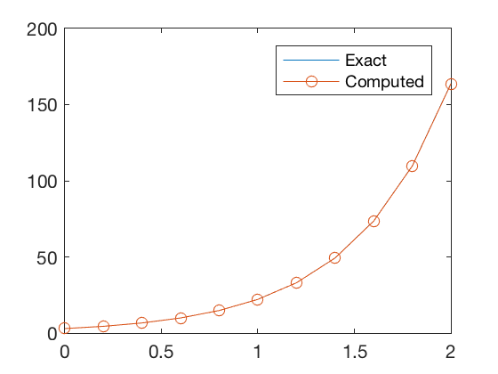

```
ans =

         0
    0.0003
    0.0008
    0.0018
    0.0036
    0.0068
    0.0121
    0.0211
    0.0361
    0.0605
    0.1003
```

```matlab
% Define f(x)
f = @(x) ( 2*x);
h = 0.2;
t0 = 0;
T = 2;
t = t0:h:T;
x0=3;
xexact = 3*exp(2*t);
[tlist wlist] = rk4(f,x0,h,t0,T);
plot(t,xexact,t,wlist,'-o')
legend('Exact','Computed')
abs(wlist-xexact')
```

$$ x'(t)=x(t) - t^2 + 1,\quad t>0, \quad x(0)=0.5. $$

Compute $x(4)$. The exact solutions is

$$ x(t)=t^2 +2 t+1 -\frac{1}{2}e^t. $$

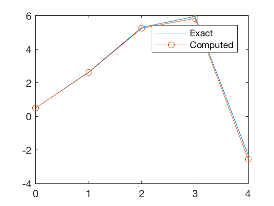

```
xexact =

    0.5000    2.6409    5.3055    5.9572   -2.2991


ans =

         0
    0.0159
    0.0503
    0.1202
    0.2465
```

```matlab
f = @(t,y) (y - t^2 +1);
h=1;

t0=0;
tf=4;
x0=0.5;
t=t0:h:tf;
xexact = t.^2 + 2*t +1 -0.5*exp(t);
%rk4(f,x0,dt,ti,tf)
[tlist,wlist] = rk4_na(f,x0,h,t0,tf);
xexact
plot(t,xexact,t,wlist,'-o')
legend('Exact','Computed')
abs(xexact'-wlist)
```

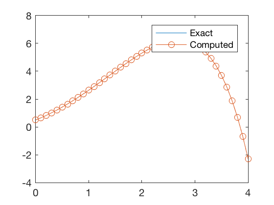

```
ans =

   1.0e-04 *

         0
    0.0017
    0.0034
    0.0054
    0.0075
    0.0097
    0.0121
    0.0147
    0.0175
    0.0204
    0.0236
    0.0270
    0.0307
    0.0346
    0.0388
    0.0432
    0.0479
    0.0529
    0.0583
    0.0639
    0.0699
    0.0762
    0.0828
    0.0898
    0.0971
    0.1047
    0.1127
    0.1209
    0.1294
    0.1381
    0.1470
    0.1561
    0.1652
    0.1742
    0.1832
    0.1918
    0.2000
    0.2076
    0.2144
    0.2201
    0.2244
```

```matlab
f = @(t,y) (y - t^2 +1);
h=0.1;

t0=0;
tf=4;
x0=0.5;
t=t0:h:tf;
xexact = t.^2 + 2*t +1 -0.5*exp(t);
%rk4(f,x0,dt,ti,tf)
[tlist,wlist] = rk4_na(f,x0,h,t0,tf);
plot(t,xexact,t,wlist,'-o')
legend('Exact','Computed')
abs(xexact'-wlist)
```

How about comparing results with RK2 (the modified Euler version)?

```matlab
%%file rk2_na.m
function [tlist,w] = rk2_na(f,x0,dt,ti,tf)
    nn = floor((tf - ti)/dt);
    dtfinal = tf - (ti + nn*dt);
    if dtfinal==0
        w = zeros(nn+1,1);
        tlist = ti:dt:tf;
    else
        w = zeros(nn+2,1);
        tlist = [ti:dt:tf, tf];
    end
    w(1) = x0;
    for i = 1:nn
        w(i+1) = w(i) + dt*f(tlist(i)+0.5*dt, w(i) + 0.5*dt*f(tlist(i),w(i)));
%         fprintf('Step %d:  w = %18.15f\n', i, w(i+1));
    end
    if dtfinal ~= 0
        w(nn+2) = w(nn+1) + dt*f(tlist(nn+1)+0.5*dt, w(nn+1) + 0.5*dt*f(tlist(nn+1),w(nn+1)));
%         fprintf('Step %d:  w = %18.15f\n', nn+2, w(nn+2));
    end
end
```

```
Created file '/Users/denizbilman/Dropbox/Teaching/umich Math471/jupyterLectures/rk2_na.m'.
```

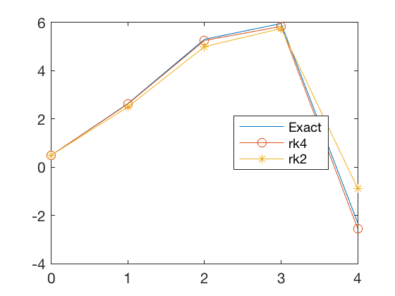

```matlab
f = @(t,y) (y - t^2 +1);
h=1;

t0=0;
tf=4;
x0=0.5;
t=t0:h:tf;
xexact = t.^2 + 2*t +1 -0.5*exp(t);
%rk4(f,x0,dt,ti,tf)
[tlist,wlist4] = rk4_na(f,x0,h,t0,tf);
[tlist,wlist2] = rk2_na(f,x0,h,t0,tf);
plot(t,xexact,t,wlist4,'-o',t,wlist2,'-*')
legend('Exact','rk4','rk2','Location', 'Best')
% abs(xexact'-wlist)
```

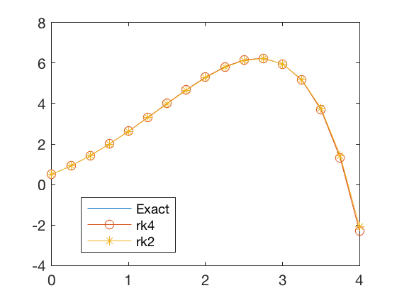

```matlab
f = @(t,y) (y - t^2 +1);
h=0.25;

t0=0;
tf=4;
x0=0.5;
t=t0:h:tf;
xexact = t.^2 + 2*t +1 -0.5*exp(t);
%rk4(f,x0,dt,ti,tf)
[tlist,wlist4] = rk4_na(f,x0,h,t0,tf);
[tlist,wlist2] = rk2_na(f,x0,h,t0,tf);
plot(t,xexact,t,wlist4,'-o',t,wlist2,'-*')
legend('Exact','rk4','rk2','Location', 'Best')
% abs(xexact'-wlist)
```

Let's solve

$$ x'(t) = -2 y(t) - \cos(4t),\quad t>0,\quad x(0)=3. $$

$$ x(t)=-\frac{1}{10} e^{-2 t} \left(2 e^{2 t} \sin (4 t)+e^{2 t} \cos (4 t)-31\right) $$

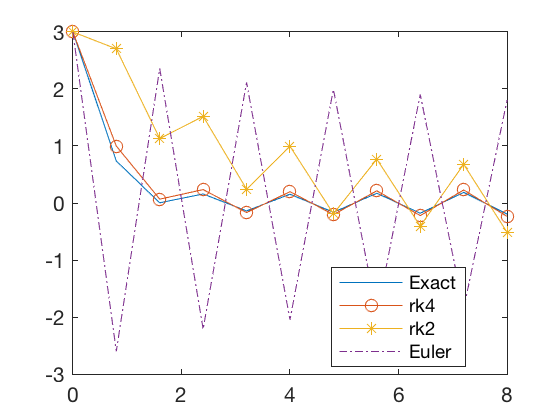

```matlab
%FULL COMPARISON
f = @(t,y) (-2*y - cos(4*t));
h=0.8;

t0=0;
tf=8;
x0=3;
t=t0:h:tf;
%xexact = 0.1*cos(4*t)+0.2*sin(4*t)+2.9*exp(-2*t);  % Exact Solution
xexact = -0.1*(2*sin(4*t)+ cos(4*t)-31*exp(-2*t) );
%rk4(f,x0,dt,ti,tf)
[tlist,wlist4] = rk4_na(f,x0,h,t0,tf);
[tlist,wlist2] = rk2_na(f,x0,h,t0,tf);
[tlist,wlistEuler] = euler_na(f,x0,h,t0,tf);
plot(t,xexact,t,wlist4,'-o',t,wlist2,'-*',t, wlistEuler,'-.')
legend('Exact','rk4','rk2','Euler','Location', 'Best')
% abs(xexact'-wlist)
```

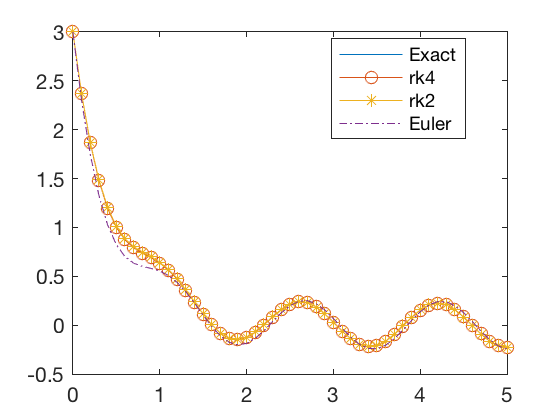

```matlab
%FULL COMPARISON
f = @(t,y) (-2*y - cos(4*t));
h=0.1;

t0=0;
tf=5;
x0=3;
t=t0:h:tf;
%xexact = 0.1*cos(4*t)+0.2*sin(4*t)+2.9*exp(-2*t);  % Exact Solution
xexact = -0.1*(2*sin(4*t)+ cos(4*t)-31*exp(-2*t) );
%rk4(f,x0,dt,ti,tf)
[tlist,wlist4] = rk4_na(f,x0,h,t0,tf);
[tlist,wlist2] = rk2_na(f,x0,h,t0,tf);
[tlist,wlistEuler] = euler_na(f,x0,h,t0,tf);
plot(t,xexact,t,wlist4,'-o',t,wlist2,'-*',t, wlistEuler,'-.')
legend('Exact','rk4','rk2','Euler','Location', 'Best')
% abs(xexact'-wlist)
```

## Multi-step Methods

### Two-step (explicit) Adams-Bashforth Method

We need two starting points

$$ w_0 = x_0,\quad w_1= x_1, $$

where $x_1$ is computed first from $x_0$ using a simple time-stepping method. Then the explicit two-step Adams-Bashforth Method is given by

$$ w_{i+1} = w_i + \frac{1}{2}\Delta t \left(3f(t_i,w_i) - f(t_{i-1},w_{i-1}) \right). $$

```matlab
%%file ab2_na.m
function [tlist,w] = ab2_na(f,x0,dt,ti,tf)
    nn = floor((tf - ti)/dt);
    dtfinal = tf - (ti + nn*dt);
    if dtfinal==0
        w = zeros(nn+1,1);
        tlist = ti:dt:tf;
    else
        w = zeros(nn+2,1);
        tlist = [ti:dt:tf, tf];
    end
    w(1) = x0;
    % Do simple Euler to compute the first-iterate:
    w(2) = w(1) + dt*f(tlist(1),w(1));
    for i = 2:nn
        w(i+1) = w(i) + 0.5*dt*(3*f(tlist(i), w(i))-f(tlist(i-1), w(i-1)));
%         fprintf('Step %d:  w = %18.15f\n', i, w(i+1));
    end
    if dtfinal ~= 0
        w(nn+2) = w(nn+1) + 0.5*dt*( 3*f(tlist(nn+1), w(nn+1)) - f(tlist(nn), w(nn+1)) );
%         fprintf('Step %d:  w = %18.15f\n', nn+2, w(nn+2));
    end
end
```

```
Created file '/Users/denizbilman/Dropbox/Teaching/umich Math471/jupyterLectures/ab2_na.m'.
```

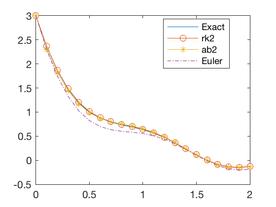

```matlab
%FULL COMPARISON
f = @(t,y) (-2*y - cos(4*t));
h=0.1;

t0=0;
tf=2;
x0=3;
t=t0:h:tf;
%xexact = 0.1*cos(4*t)+0.2*sin(4*t)+2.9*exp(-2*t);  % Exact Solution
xexact = -0.1*(2*sin(4*t)+ cos(4*t)-31*exp(-2*t) );
%rk4(f,x0,dt,ti,tf)
[tlist,wlist4] = rk4_na(f,x0,h,t0,tf);
[tlist,wlist2] = rk2_na(f,x0,h,t0,tf);
[tlist,wlistEuler] = euler_na(f,x0,h,t0,tf);
[tlist,wlistab2] = ab2_na(f,x0,h,t0,tf);
plot(t,xexact,t,wlist2,'-o',t,wlistab2,'-*',t, wlistEuler,'-.')
legend('Exact','rk2','ab2','Euler','Location', 'Best')
% abs(xexact'-wlist)
```

## Multi-step Methods

### Four-step (explicit) Adams-Bashforth Method

We need four starting points

$$ w_0 = x_0,\quad w_1= x_1, \quad w_2= x_3, \quad w_3= x_3, $$

where $x_k$, $k=1,2,3$ are computed first from $x_0$ using another time-stepping method. Then the explicit four-step Adams-Bashforth Method is given by

$$ w_{i+1} = w_i + \frac{1}{24}\Delta t \left( 55 f(t_i,w_i) - 59 f(t_{i-1},w_{i-1} + 37 f(t_{i-2},w_{i-2}) - 9 f(t_{i-3},w_{i-3} \right), $$

for $i=3,\dots$.

```matlab
%%file ab4_na.m
function [tlist,w] = ab4_na(f,x0,dt,ti,tf)
    nn = floor((tf - ti)/dt);
    dtfinal = tf - (ti + nn*dt);
    if dtfinal==0
        w = zeros(nn+1,1);
        tlist = ti:dt:tf;
    else
        w = zeros(nn+2,1);
        tlist = [ti:dt:tf, tf];
    end
    w(1) = x0;
    % Do RK4 to compute the first 3 iterates:
    tftemp=(ti+3*dt)
    tstart = ti:dt:tftemp;
    wstart = zeros(3,1);
    [tstart, wstart] = rk4_na(f,x0,dt,ti,tftemp);
    w(1:4)=wstart(1:4);
    for i = 4:nn
        w(i+1) = w(i) + (1/24)*dt*(55*f(tlist(i), w(i)) - 59*f(tlist(i-1), w(i-1)) + 37*f(tlist(i-2), w(i-2)) - 9*f(tlist(i-3), w(i-3)));
%         fprintf('Step %d:  w = %18.15f\n', i, w(i+1));
    end
    if dtfinal ~= 0
        w(nn+2) = w(nn+1) + (1/24)*dt*(55*f(tlist(nn+1), w(nn+1)) - 59*f(tlist(nn+1-1), w(nn+1-1)) + 37*f(tlist(nn+1-2), w(nn+1-2)) - 9*f(tlist(nn+1-3), w(nn+1-3)));
%         fprintf('Step %d:  w = %18.15f\n', nn+2, w(nn+2));
    end
end
```

```
Created file '/Users/denizbilman/Dropbox/Teaching/umich Math471/jupyterLectures/ab4_na.m'.
```

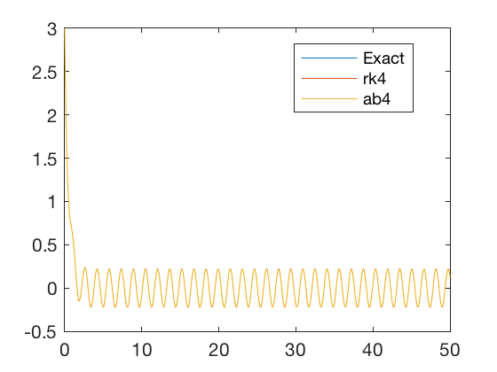

```
tftemp =

    0.3000


ans =

    3.0000
    2.3681
    1.8649
    1.4787
    1.1959


ans =

    3.0000
    2.3681
    1.8649
    1.4787
    1.1964
```

```matlab
%FULL COMPARISON
f = @(t,y) (-2*y - cos(4*t));
h=0.1;

t0=0;
tf=50;
x0=3;
t=t0:h:tf;
%xexact = 0.1*cos(4*t)+0.2*sin(4*t)+2.9*exp(-2*t);  % Exact Solution
xexact = -0.1*(2*sin(4*t)+ cos(4*t)-31*exp(-2*t) );
%rk4(f,x0,dt,ti,tf)
[tlist,wlist4] = rk4_na(f,x0,h,t0,tf);
[tlist,wlist2] = rk2_na(f,x0,h,t0,tf);
[tlist,wlistEuler] = euler_na(f,x0,h,t0,tf);
[tlist,wlistab2] = ab2_na(f,x0,h,t0,tf);
[tlist,wlistab4] = ab4_na(f,x0,h,t0,tf);
plot(t,xexact,t,wlist4,'-',t,wlistab4,'-')
legend('Exact','rk4','ab4','Location', 'Best')
% abs(xexact'-wlist)
wlist4(1:5)
wlistab4(1:5)
```

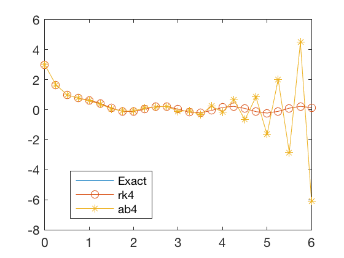

```
tftemp =

    0.7500


ans =

    3.0000
    1.6588
    1.0013
    0.7634
    0.6369


ans =

    3.0000
    1.6588
    1.0013
    0.7634
    0.6002
```

```matlab
%FULL COMPARISON
f = @(t,y) (-2*y - cos(4*t));
h=0.25;

t0=0;
tf=6;
x0=3;
t=t0:h:tf;
%xexact = 0.1*cos(4*t)+0.2*sin(4*t)+2.9*exp(-2*t);  % Exact Solution
xexact = -0.1*(2*sin(4*t)+ cos(4*t)-31*exp(-2*t) );
%rk4(f,x0,dt,ti,tf)
[tlist,wlist4] = rk4_na(f,x0,h,t0,tf);
[tlist,wlist2] = rk2_na(f,x0,h,t0,tf);
[tlist,wlistEuler] = euler_na(f,x0,h,t0,tf);
[tlist,wlistab2] = ab2_na(f,x0,h,t0,tf);
[tlist,wlistab4] = ab4_na(f,x0,h,t0,tf);
plot(t,xexact,t,wlist4,'-o',t,wlistab4,'-*')
legend('Exact','rk4','ab4','Location', 'Best')
% abs(xexact'-wlist)
wlist4(1:5)
wlistab4(1:5)
```

A stiff example:

$$ x'(t)=-30 x(t),\quad t>0,\quad x(0)=\frac{1}{3}. $$

Exact solution is $x(t)=\frac{1}{3}e^{-30 t}$. It is not straightforward to compute this very small, decaying solution accurately.

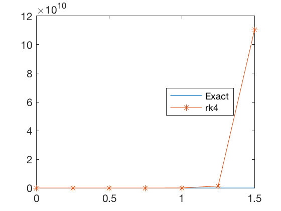

```matlab
%FULL COMPARISON
f = @(y) (-30*y);
h=0.25;

t0=0;
tf=1.5;
x0=1/3;
t=t0:h:tf;
%xexact = 0.1*cos(4*t)+0.2*sin(4*t)+2.9*exp(-2*t);  % Exact Solution
xexact = x0*exp(-30*t);
%rk4(f,x0,dt,ti,tf)
[tlist,wlist4] = rk4(f,x0,h,t0,tf);
plot(t,xexact,t,wlist4,'-*')
legend('Exact','rk4','Location', 'Best')
% abs(xexact'-wlist)
```

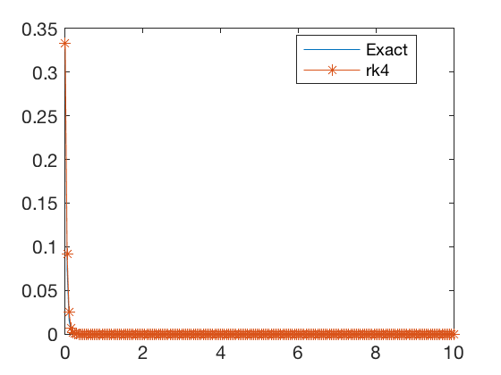

```matlab
%FULL COMPARISON
f = @(y) (-30*y);
h=0.05;

t0=0;
tf=10;
x0=1/3;
t=t0:h:tf;
%xexact = 0.1*cos(4*t)+0.2*sin(4*t)+2.9*exp(-2*t);  % Exact Solution
xexact = x0*exp(-30*t);
%rk4(f,x0,dt,ti,tf)
[tlist,wlist4] = rk4(f,x0,h,t0,tf);
plot(t,xexact,t,wlist4,'-*')
legend('Exact','rk4','Location', 'Best')
% abs(xexact'-wlist)
```

Can also solve the IVP for a linear second order ODE:

$$ y''(t) + y'(t) - 6 y(t) =0,\quad y(0)=3,\quad y'(0)=1. $$

Set $z(t):=y'(t)$. Then $z'(t)=-z(t)+6y(t)$.

$$ \mathbf{x}(t):=\begin{pmatrix} y(t)\\z(t) \end{pmatrix}. $$

Then the IVP problem is equivalent to the following (autonomous) first order system:

$$ \mathbf{x}'(t) = \begin{pmatrix} 0 & 1 \\ 6 & -1 \end{pmatrix}\mathbf{x}(t) $$

Then the exact solution is

$$ \mathbf{x}(t) = \begin{pmatrix} e^{-3t}+2e^{2t}\\-3e^{-3t}+4e^{2t}\end{pmatrix}. $$

So that $y(t)=e^{-3t}+2e^{2t}$.

```matlab
%%file rk4_ND.m
function [tlist,w] = rk4(f,x0,dt,ti,tf,Ndim)
    nn = floor((tf - ti)/dt);
    dtfinal = tf - (ti + nn*dt);
    if dtfinal==0
        w = zeros(nn+1,Ndim);
        tlist = ti:dt:tf;
    else
        w = zeros(nn+2,Ndim);
        tlist = [ti:dt:tf, tf];
    end
    w(1,:) = x0;
    for i = 1:nn
        k1 = dt*f(w(i,:));
        k2 = dt*f(w(i,:) + 0.5.*k1);
        k3 = dt*f(w(i,:) + 0.5.*k2);
        k4 = dt*f(w(i,:) + k3);
        w(i+1,:) = w(i,:) + (k1 + 2*k2 + 2*k3 + k4)/6.;
        %fprintf('Step %d:  w = %18.15f\n', i, w(i+1));
    end
    if dtfinal ~= 0
        dt = dtfinal;
        k1 = dt*f(w(nn+1,:));
        k2 = dt*f(w(nn+1,:) + 0.5.*k1);
        k3 = dt*f(w(nn+1,:) + 0.5.*k2);
        k4 = dt*f(w(nn+1,:) + k3);
        w(nn+2,:) = w(nn+1,:) + (1/6)*(k1 + 2*k2 + 2*k3 + k4);
        %fprintf('Step %d:  w = %18.15f\n', nn+2, w(nn+2));
    end
end
```

```
Created file '/Users/denizbilman/Dropbox/Teaching/umich Math471/jupyterLectures/rk4_ND.m'.
```

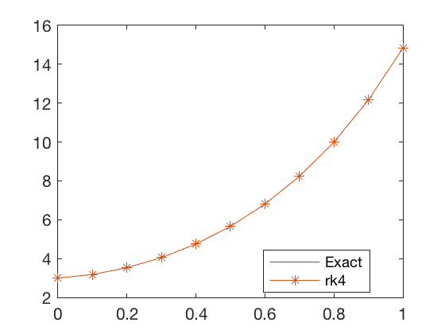

```matlab
f = @(x) ([x(2), 6*x(1)-x(2)]);
h=0.1;

t0=0;
tf=1;
x0=[3 1];
t=t0:h:tf;
%xexact = 0.1*cos(4*t)+0.2*sin(4*t)+2.9*exp(-2*t);  % Exact Solution
xexact = exp(-3*t) + 2*exp(2*t);
%rk4(f,x0,dt,ti,tf)
[tlist,ww] = rk4_ND(f,x0,h,t0,tf,2);
plot(t,xexact,t,ww(:,1),'-*')
legend('Exact','rk4','Location', 'Best')
```

## References

Some of the material is based on the textbook for this course:  
[Bradie] *A Friendly Introduction to Numerical Analysis*, by Brian Bradie, Pearson 2006.

```matlab
w = zeros(5,2)
 w(1,:)
```

```
w =

     0     0
     0     0
     0     0
     0     0
     0     0


ans =

     0     0
```